# First-Steps: Processing Project Data

We can also use `samtools flagstat` to determine information about our mappings. Below I have written some code to loop over all of my alignment files, appending the `samtools flagstat` output to their respective output files.

```bash
untrimmed_bam_files=$(ls /home/t730/angsd/alignments | grep -e "SRR[0-9]*.Aligned.*.bam$")
trimmed_bam_files=$(ls /home/t730/angsd/alignments | grep -e "SRR[0-9]*_trimmed.Aligned.*.bam$")

trimmed_out_file="trimmed_bam_quality.txt"
untrimmed_out_file="untrimmed_bam_quality.txt"

rm $trimmed_out_file $untrimmed_out_file

for file in $untrimmed_bam_files ; do
  echo -e "===================================" >> $untrimmed_out_file
  echo -e "${file}\n" >> $untrimmed_out_file
  samtools flagstat $file >> $untrimmed_out_file
  echo -e "===================================\n" >> $untrimmed_out_file
done

for file in $trimmed_bam_files ; do
  echo -e "===================================" >> $trimmed_out_file
  echo -e "${file}\n" >> $trimmed_out_file
  samtools flagstat $file >> $trimmed_out_file
  echo -e "===================================\n" >> $trimmed_out_file
done
```

This leaves us with entires in the output files like this

```bash
===================================
SRR8440482_trimmed.Aligned.sortedByCoord.out.bam

64996775 + 0 in total (QC-passed reads + QC-failed reads)
30094645 + 0 secondary
0 + 0 supplementary
0 + 0 duplicates
64996775 + 0 mapped (100.00% : N/A)
0 + 0 paired in sequencing
0 + 0 read1
0 + 0 read2
0 + 0 properly paired (N/A : N/A)
0 + 0 with itself and mate mapped
0 + 0 singletons (N/A : N/A)
0 + 0 with mate mapped to a different chr
0 + 0 with mate mapped to a different chr (mapQ>=5)
===================================
```

**Samtools Coverage**

`samotols coverage` can help us understand the first step of alignment, seeing roughly where alighments have been assigned to and plot their coverage with the `--histogram` option to print an ascii histogram representation of the coverage of each chromosome/feature/segment to the terminal. The **first two** histograms are shown below.

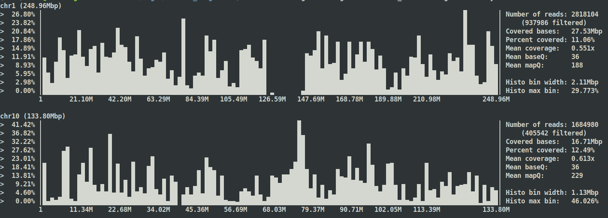

```bash
samtools coverage --histogram SRR8440443_trimmed.Aligned.sortedByCoord.out.bam
```

### **Calculating Unmapped Reads**

```bash
bam_files=$(ls /home/t730/angsd/trimmed_alignments/*.bam)

for bam_file in $bam_files; do
  base=$(basename $bam_file)
  prefix=$(echo $base | egrep -o "SRR[0-9]+")

  num_lines=$(cat ${prefix}_trimmed.Unmapped.out.mate1 | wc -l)
  num_total_lines=$(zcat ../trimmed_myeloid_cells/${prefix}_trimmed.fq.gz | wc -l)
  perc_unmapped_reads=$(echo -e "(${num_lines}/${num_total_lines})*100" | bc -l | xargs printf %.2f)
  echo -e "Percentage of unmapped reads for ${prefix}: ${perc_unmapped_reads}%"
done
```

```bash
Percentage of unmapped reads for SRR8440443: 5.90%
Percentage of unmapped reads for SRR8440448: 4.04%
Percentage of unmapped reads for SRR8440463: 33.79%
Percentage of unmapped reads for SRR8440477: 5.14%
Percentage of unmapped reads for SRR8440482: 6.54%
Percentage of unmapped reads for SRR8440501: 6.98%
Percentage of unmapped reads for SRR8440511: 5.47%
Percentage of unmapped reads for SRR8440514: 4.97%
Percentage of unmapped reads for SRR8440518: 5.02%
Percentage of unmapped reads for SRR8440524: 11.28%
Percentage of unmapped reads for SRR8440538: 7.43%
Percentage of unmapped reads for SRR8440539: 12.34%
```

We see that sample `SRR8440463` showed a very high amount of unmapped reads. This is the same sample that showed issues in the **Per Sequence GC Content** plot before, thus providing us more evident that this sample should be considered for not being included in the study.